# Reproducible Data - Course Project 1

## Loading useful packages, loading and pre-processing the data

As part of the processing of the raw data, I used functions from the dpylr and lubridate packages. ggplot2 was used to create the explanatory graphics. After loading the packages, I read the data file from my working directory and stored the output in “activity”.

```r
activity <- read.csv("~/activity.csv")
```

## What is the mean total number of steps taken per day?

“activity.csv” is data generated by a fitness wearable device. The device recorded the number of steps taken throughout every day for two months. The recordings were done in five minute intervals. To discover the mean total number of steps per day recorded during the two month period of data collection, I constructed a separate data frame that matched the total steps to the corresponding date. Thereafter, I computed the mean and median of all total steps per day recorded over that two month period.

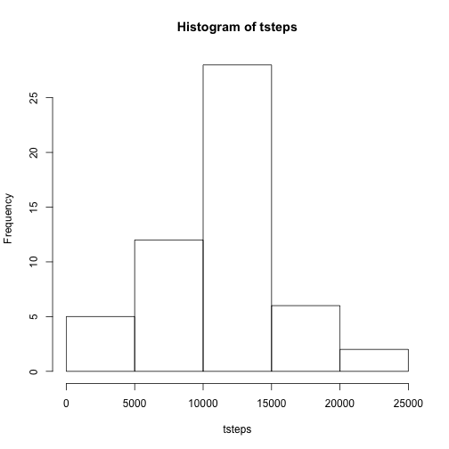

```r
sumsteps <- activity %>% group_by(date) %>%
                summarise(sum(steps))

names(sumsteps) <- c("date", "tsteps")

with(sumsteps, hist(tsteps))
```

```r
mean(sumsteps$tsteps, na.rm = TRUE)
```

```
## [1] 10766.19
```

```r
median(sumsteps$tsteps, na.rm = TRUE)
```

```
## [1] 10765
```

## What is the average daily activity pattern?

Which interval during the day, on average, records the greatest activity? The following creates a new data frame that computes the average amount of steps taken, on average, for each interval during a given day. A plot visualizes the average steps across the intervals. I then calculate the exact interval recording the average maximum amount of steps taken in a given day. The 835 minute interval records the greatest activity, on average, in a given day.

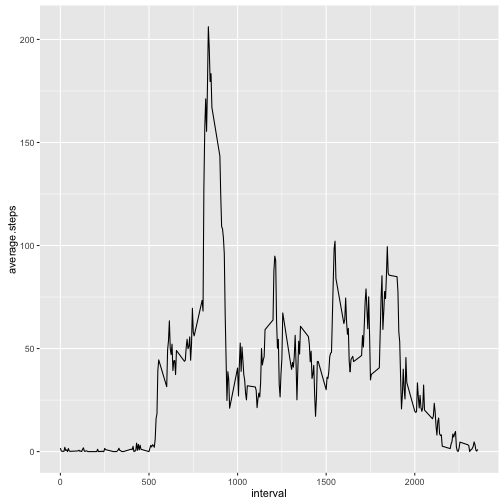

```r
avgsteps <- activity %>% group_by(interval) %>%
                summarise(mean(steps, na.rm = TRUE))

names(avgsteps) <- c("interval", "average.steps")

ggplot(avgsteps, aes(interval, average.steps)) + geom_line()
```

```r
m <- max(avgsteps$average.steps)
subset(avgsteps, average.steps == m)
```

```
## Source: local data frame [1 x 2]
##
##   interval average.steps
##      (int)         (dbl)
## 1      835      206.1698
```

## Imputing missing values

In previous steps, I removed all NA values in calculating step summaries. In the current step, I redefine the NA values to be the mean step value for that interval in a given day, and recalculate the mean and median total steps taken per day. The results show little to no difference.

```r
sum(is.na(activity))
```

```
## [1] 2304
```

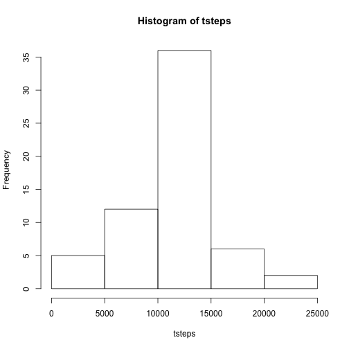

```r
nona <- activity
for (i in 1:nrow(nona)) {
        if(is.na(nona$steps[i]) == TRUE) {
                x <- nona$interval[i]
                nona$steps[i] <- as.numeric(subset(avgsteps, interval == x, average.steps))

        }
}

nonasumsteps <- nona %>% group_by(date) %>%
        summarise(sum(steps))

names(nonasumsteps) <- c("date", "tsteps")

with(nonasumsteps, hist(tsteps))
```

```r
mean(nonasumsteps$tsteps)
```

```
## [1] 10766.19
```

```r
median(nonasumsteps$tsteps)
```

```
## [1] 10766.19
```

## Are there differences in activity patterns between weekdays and weekends?

I create a factor variable to indicate whether the date corresponding to a given observation is a weekday or weekend. I then construct a plot measuring average steps taken in a given day during all intervals. As is illustrated in the plot, activity levels increases/decreases were mostly correlated with each other, however, the magnitude of such changes differed. To note, this plot utilizes the data frame with substituted NA values generated in the previous heading.

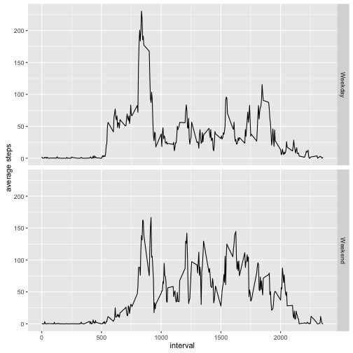

```r
newdate <- ymd(nona$date)
nona2 <- nona
nona2$date <- newdate
nona2$day_of_week <- wday(nona2$date)
wk <- as.character()

for(i in 1:nrow(nona2)) {
        if(nona2$day_of_week[i] == 1 | nona2$day_of_week[i] == 7) {
                wk[i] <- as.character("Weekend")
        }
        if(nona2$day_of_week[i] == 2 | nona2$day_of_week[i] == 3 | nona2$day_of_week[i] == 4 | nona2$day_of_week[i] == 5 | nona2$day_of_week[i] == 6)
                wk[i] <- as.character("Weekday")
}
nona2$wk.o <- as.factor(wk)
nona2 <- nona2 %>% select(steps, date, interval, wk.o)

avg.nona2 <- nona2 %>% group_by(interval, wk.o) %>%
        summarise(avg.steps = mean(steps))

qplot(interval, avg.steps, data = avg.nona2, facets = wk.o~., geom = "line", ylab = "average steps")
```